# Desafio - 11

Iuri Santos Oliveira

```r
data_hora_geracao <- format(Sys.time(), "%Y-%m-%d %H:%M:%S")
cat("Relatório gerado em:", data_hora_geracao, "\n\n")
```

```
## Relatório gerado em: 2025-10-07 10:51:31
```

# Conjunto de Dados

O conjunto de dados “Renda Adulta” contém informações demográficas e econômicas de indivíduos, que são utilizadas para prever se um indivíduo ganha mais ou menos de $50.000 por ano.

```python
#!pip install plotnine
```

## Atividade

```python
import polars as pl
import plotnine as p9

# Definir nomes das colunas
nomescol = [
    "age", "workclass", "fnlwgt", "education", "education-num",
    "marital-status", "occupation", "relationship", "race", "sex",
    "capital-gain", "capital-loss", "hours-per-week", "native-country", "income"
]

# Definir tipos das colunas
tiposcol = {
    "age": pl.Int64,
    "workclass": pl.Utf8,
    "fnlwgt": pl.Int64,
    "education": pl.Utf8,
    "education-num": pl.Int64,
    "marital-status": pl.Utf8,
    "occupation": pl.Utf8,
    "relationship": pl.Utf8,
    "race": pl.Utf8,
    "sex": pl.Utf8,
    "capital-gain": pl.Int64,
    "capital-loss": pl.Int64,
    "hours-per-week": pl.Int64,
    "native-country": pl.Utf8,
    "income": pl.Utf8
}

# Importar o arquivo CSV
df = pl.read_csv(
    "../dados/renda_adulta.csv.gz",
    has_header=False, # Indica que o arquivo CSV NÃO tem uma linha de cabeçalho
    new_columns=nomescol,
    dtypes=tiposcol,
    null_values=["?", " ?"]  # Tratar as (? ) como valores faltantes
)
# Remover espaços em branco das colunas de texto
for col in df.columns:
    if df[col].dtype == pl.Utf8:
        df = df.with_columns(pl.col(col).str.strip_chars())

df.head()
```

shape: (5, 15)

| age i64 | workclass str | fnlwgt i64 | education str | education-num i64 | marital-status str | occupation str | relationship str | race str | sex str | capital-gain i64 | capital-loss i64 | hours-per-week i64 | native-country str | income str |
| --- | --- | --- | --- | --- | --- | --- | --- | --- | --- | --- | --- | --- | --- | --- |
| 39 | "State-gov" | 77516 | "Bachelors" | 13 | "Never-married" | "Adm-clerical" | "Not-in-family" | "White" | "Male" | 2174 | 0 | 40 | "United-States" | "<=50K" |
| 50 | "Self-emp-not-inc" | 83311 | "Bachelors" | 13 | "Married-civ-spouse" | "Exec-managerial" | "Husband" | "White" | "Male" | 0 | 0 | 13 | "United-States" | "<=50K" |
| 38 | "Private" | 215646 | "HS-grad" | 9 | "Divorced" | "Handlers-cleaners" | "Not-in-family" | "White" | "Male" | 0 | 0 | 40 | "United-States" | "<=50K" |
| 53 | "Private" | 234721 | "11th" | 7 | "Married-civ-spouse" | "Handlers-cleaners" | "Husband" | "Black" | "Male" | 0 | 0 | 40 | "United-States" | "<=50K" |
| 28 | "Private" | 338409 | "Bachelors" | 13 | "Married-civ-spouse" | "Prof-specialty" | "Wife" | "Black" | "Female" | 0 | 0 | 40 | "Cuba" | "<=50K" |

2. Apresente os tipos de cada uma das coluna.

```python
for col in df.columns:
    print(f"{col:20} -> {df[col].dtype}")
```

```
## age                  -> Int64
## workclass            -> String
## fnlwgt               -> Int64
## education            -> String
## education-num        -> Int64
## marital-status       -> String
## occupation           -> String
## relationship         -> String
## race                 -> String
## sex                  -> String
## capital-gain         -> Int64
## capital-loss         -> Int64
## hours-per-week       -> Int64
## native-country       -> String
## income               -> String
```

```python
print()
```

3. Apresente as dimensões da tabela de dados.

```python
linhas, colunas = df.shape
print(f"Dimensões: {linhas} x {colunas}\n")
```

```
## Dimensões: 32561 x 15
```

4. Quantas pessoas recebem acima de $50.000 e quantas pessoas recebem abaixo deste limiar?

```python
acima_50k = df.filter(pl.col("income") == ">50K").height
abaixo_50k = df.filter(pl.col("income") == "<=50K").height
print(f"Pessoas com renda > $50.000: {acima_50k}")
```

```
## Pessoas com renda > $50.000: 7841
```

```python
print(f"Pessoas com renda <= $50.000: {abaixo_50k}")
```

```
## Pessoas com renda <= $50.000: 24720
```

5. Crie um objeto chamado `renda_longo`, no qual você transforma as colunas `capital-gain` e `capital-loss` (formato wide) para formato longo. Os valores destas variáveis devem ser armazenados numa nova coluna chamada `Valor` e os tipos de valores (`gain` e `loss`) devem ser armazenados numa coluna chamada `tipo`.

```python
renda_longo = df.melt( # Converte colunas em linhas
    id_vars=[col for col in df.columns if col not in ["capital-gain", "capital-loss"]], # Mantém TODAS as colunas EXCETO "capital-gain" e "capital-loss" como identificadores
    value_vars=["capital-gain", "capital-loss"], #Especifica que "capital-gain" e "capital-loss" serão transformadas em linhas
    variable_name="tipo", # Cria uma nova coluna chamada "tipo" que dirá se é "gain" ou "loss"
    value_name="Valor" # Cria uma coluna "Valor" com os valores numéricos
)
# Remove o prefixo "capital-" da coluna "tipo"
renda_longo = renda_longo.with_columns(
    pl.col("tipo").str.replace("capital-", "")
)

renda_longo.head(10)
```

shape: (10, 15)

| age i64 | workclass str | fnlwgt i64 | education str | education-num i64 | marital-status str | occupation str | relationship str | race str | sex str | hours-per-week i64 | native-country str | income str | tipo str | Valor i64 |
| --- | --- | --- | --- | --- | --- | --- | --- | --- | --- | --- | --- | --- | --- | --- |
| 39 | "State-gov" | 77516 | "Bachelors" | 13 | "Never-married" | "Adm-clerical" | "Not-in-family" | "White" | "Male" | 40 | "United-States" | "<=50K" | "gain" | 2174 |
| 50 | "Self-emp-not-inc" | 83311 | "Bachelors" | 13 | "Married-civ-spouse" | "Exec-managerial" | "Husband" | "White" | "Male" | 13 | "United-States" | "<=50K" | "gain" | 0 |
| 38 | "Private" | 215646 | "HS-grad" | 9 | "Divorced" | "Handlers-cleaners" | "Not-in-family" | "White" | "Male" | 40 | "United-States" | "<=50K" | "gain" | 0 |
| 53 | "Private" | 234721 | "11th" | 7 | "Married-civ-spouse" | "Handlers-cleaners" | "Husband" | "Black" | "Male" | 40 | "United-States" | "<=50K" | "gain" | 0 |
| 28 | "Private" | 338409 | "Bachelors" | 13 | "Married-civ-spouse" | "Prof-specialty" | "Wife" | "Black" | "Female" | 40 | "Cuba" | "<=50K" | "gain" | 0 |
| 37 | "Private" | 284582 | "Masters" | 14 | "Married-civ-spouse" | "Exec-managerial" | "Wife" | "White" | "Female" | 40 | "United-States" | "<=50K" | "gain" | 0 |
| 49 | "Private" | 160187 | "9th" | 5 | "Married-spouse-absent" | "Other-service" | "Not-in-family" | "Black" | "Female" | 16 | "Jamaica" | "<=50K" | "gain" | 0 |
| 52 | "Self-emp-not-inc" | 209642 | "HS-grad" | 9 | "Married-civ-spouse" | "Exec-managerial" | "Husband" | "White" | "Male" | 45 | "United-States" | ">50K" | "gain" | 0 |
| 31 | "Private" | 45781 | "Masters" | 14 | "Never-married" | "Prof-specialty" | "Not-in-family" | "White" | "Female" | 50 | "United-States" | ">50K" | "gain" | 14084 |
| 42 | "Private" | 159449 | "Bachelors" | 13 | "Married-civ-spouse" | "Exec-managerial" | "Husband" | "White" | "Male" | 40 | "United-States" | ">50K" | "gain" | 5178 |

6. Quais são as médias de horas trabalhadas por classe salarial?

```python
media_horas = df.group_by("income").agg(
    pl.col("hours-per-week").mean()#Para cada grupo, calcula a média da coluna "hours-per-week"
    .alias("media_horas") # Renomeia a coluna resultante para "media_horas"
    ).sort("income") # Ordena o resultado pela coluna "income"

print(media_horas)
```

```
## shape: (2, 2)
## ┌────────┬─────────────┐
## │ income ┆ media_horas │
## │ ---    ┆ ---         │
## │ str    ┆ f64         │
## ╞════════╪═════════════╡
## │ <=50K  ┆ 38.84021    │
## │ >50K   ┆ 45.473026   │
## └────────┴─────────────┘
```

7. Se cada linha representa uma pessoa, quantas pessoas foram amostradas em cada profissão?

```python
pessoas_por_profissao = df.group_by("occupation").agg(
    pl.count() # Realiza a contagem para cada profissão
    .alias("quantidade")
).sort("quantidade", descending=True) # Ordena de forma decrescente
print(pessoas_por_profissao)
```

```
## shape: (15, 2)
## ┌─────────────────┬────────────┐
## │ occupation      ┆ quantidade │
## │ ---             ┆ ---        │
## │ str             ┆ u32        │
## ╞═════════════════╪════════════╡
## │ Prof-specialty  ┆ 4140       │
## │ Craft-repair    ┆ 4099       │
## │ Exec-managerial ┆ 4066       │
## │ Adm-clerical    ┆ 3770       │
## │ Sales           ┆ 3650       │
## │ …               ┆ …          │
## │ Farming-fishing ┆ 994        │
## │ Tech-support    ┆ 928        │
## │ Protective-serv ┆ 649        │
## │ Priv-house-serv ┆ 149        │
## │ Armed-Forces    ┆ 9          │
## └─────────────────┴────────────┘
```

8. Crie um gráfico de barras que apresente o número médio de horas trabalhadas semanalmente em função do nível salarial.

```python
# Exercício 8: Gráfico de barras - média de horas trabalhadas por nível salarial

grafico = (
    p9.ggplot(media_horas, p9.aes(x="income", y="media_horas", fill="income")) +
    p9.geom_col() +
    p9.labs(
        title="Média de Horas Trabalhadas por Semana por Nível Salarial",
        x="Nível Salarial",
        y="Média de Horas Trabalhadas por Semana"
    ) +
    p9.theme_minimal() +
    p9.theme(
        figure_size=(8, 6),
        legend_position="none"
    )
)

grafico.save("grafico_horas_salario.png", dpi=300)
import matplotlib.pyplot as plt
import matplotlib.image as mpimg

# Ler e exibir a imagem
img = mpimg.imread("grafico_horas_salario.png")
plt.figure(figsize=(10, 8))
plt.imshow(img)
plt.axis('off')  # Remove os eixos
```

```
## (np.float64(-0.5), np.float64(2399.5), np.float64(1799.5), np.float64(-0.5))
```

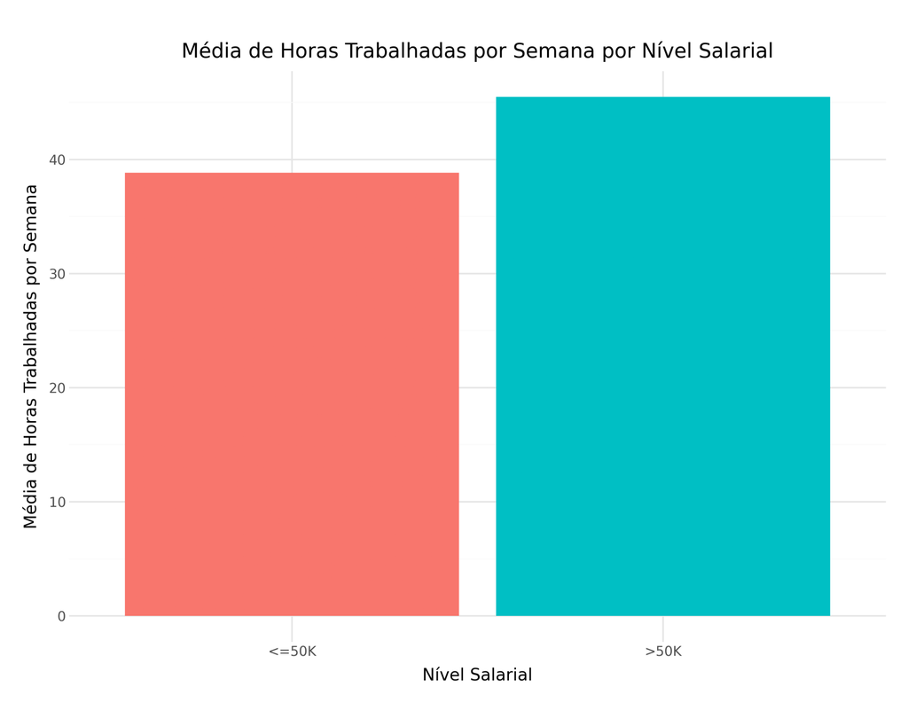

```python
plt.tight_layout()
plt.show()
```

9. Desafio: existe alguma evidência de discriminação salarial entre gêneros biológicos?

R: Com base nos dados, há uma diferença significativa na proporção de renda alta entre gêneros, drnfo que omens apresentam maior percentual de renda > $50K. Esta diferença pode ser influenciada por diversos fatores como: horas trabalhadas, tipo de ocupação, nível de educação e utros fatores socioeconômicos.

```python
# Distribuição de renda por gênero
renda_por_genero = df.group_by(["sex", "income"]).agg(
    pl.count().alias("quantidade")
).sort(["sex", "income"])
print("\nDistribuição de renda por gênero (valores absolutos):")
```

```
##
## Distribuição de renda por gênero (valores absolutos):
```

```python
print(renda_por_genero) # Distribuição de renda por gênero (valores absolutos)
```

```
## shape: (4, 3)
## ┌────────┬────────┬────────────┐
## │ sex    ┆ income ┆ quantidade │
## │ ---    ┆ ---    ┆ ---        │
## │ str    ┆ str    ┆ u32        │
## ╞════════╪════════╪════════════╡
## │ Female ┆ <=50K  ┆ 9592       │
## │ Female ┆ >50K   ┆ 1179       │
## │ Male   ┆ <=50K  ┆ 15128      │
## │ Male   ┆ >50K   ┆ 6662       │
## └────────┴────────┴────────────┘
```

```python
# Proporção de renda alta por gênero
proporcao_renda = df.group_by("sex").agg([
    pl.count().alias("total"),
    (pl.col("income") == ">50K").sum().alias("renda_alta"),
    ((pl.col("income") == ">50K").sum() / pl.count() * 100).alias("percentual_renda_alta")
]).sort("sex")
print("Proporção de pessoas com renda > $50K por gênero:")
```

```
## Proporção de pessoas com renda > $50K por gênero:
```

```python
print(proporcao_renda)
```

```
## shape: (2, 4)
## ┌────────┬───────┬────────────┬───────────────────────┐
## │ sex    ┆ total ┆ renda_alta ┆ percentual_renda_alta │
## │ ---    ┆ ---   ┆ ---        ┆ ---                   │
## │ str    ┆ u32   ┆ u32        ┆ f64                   │
## ╞════════╪═══════╪════════════╪═══════════════════════╡
## │ Female ┆ 10771 ┆ 1179       ┆ 10.946059             │
## │ Male   ┆ 21790 ┆ 6662       ┆ 30.573658             │
## └────────┴───────┴────────────┴───────────────────────┘
```

```python
# Análise mais detalhada: média de horas trabalhadas por gênero e renda
horas_genero_renda = df.group_by(["sex", "income"]).agg(
    pl.col("hours-per-week").mean().alias("media_horas"),
    pl.count().alias("n_pessoas")
).sort(["sex", "income"])
print("Média de horas trabalhadas por gênero e nível salarial:")
```

```
## Média de horas trabalhadas por gênero e nível salarial:
```

```python
print(horas_genero_renda)
```

```
## shape: (4, 4)
## ┌────────┬────────┬─────────────┬───────────┐
## │ sex    ┆ income ┆ media_horas ┆ n_pessoas │
## │ ---    ┆ ---    ┆ ---         ┆ ---       │
## │ str    ┆ str    ┆ f64         ┆ u32       │
## ╞════════╪════════╪═════════════╪═══════════╡
## │ Female ┆ <=50K  ┆ 35.916701   ┆ 9592      │
## │ Female ┆ >50K   ┆ 40.426633   ┆ 1179      │
## │ Male   ┆ <=50K  ┆ 40.693879   ┆ 15128     │
## │ Male   ┆ >50K   ┆ 46.366106   ┆ 6662      │
## └────────┴────────┴─────────────┴───────────┘
```

```python
# Análise de educação por gênero e renda
educacao_genero = df.group_by(["sex", "income"]).agg(
    pl.col("education-num").mean().alias("media_educacao")
).sort(["sex", "income"])

print("Nível médio de educação por gênero e nível salarial:")
```

```
## Nível médio de educação por gênero e nível salarial:
```

```python
print(educacao_genero)
```

```
## shape: (4, 3)
## ┌────────┬────────┬────────────────┐
## │ sex    ┆ income ┆ media_educacao │
## │ ---    ┆ ---    ┆ ---            │
## │ str    ┆ str    ┆ f64            │
## ╞════════╪════════╪════════════════╡
## │ Female ┆ <=50K  ┆ 9.820475       │
## │ Female ┆ >50K   ┆ 11.787108      │
## │ Male   ┆ <=50K  ┆ 9.452142       │
## │ Male   ┆ >50K   ┆ 11.580606      │
## └────────┴────────┴────────────────┘
```